# Project: **Finding Lane Lines on the Road**

Develop a pipeline to identify lane lines on the road. You must apply it on a series of individual images, provided in the *test_images* folder.

Once you have a result that looks roughly like the image *line-segments-example* in the examples folder (also shown below), you'll need to try to average and/or extrapolate the line segments you've detected to map out the full extent of the lane lines.

**The tools you have are color selection, region of interest selection, grayscaling, Gaussian smoothing, Canny Edge Detection and Hough Tranform line detection. You are also free to explore and try other techniques that were not presented. Your goal is piece together a pipeline to detect the line segments in the image, then average/extrapolate them and draw them onto the image for display (as below).**

[figure not shown]

Your output should look something like this (above) after detecting line segments using the helper functions below

[figure not shown]

Your goal is to connect/average/extrapolate line segments to get output like this

## Import Packages

```python
#importing some useful packages
import matplotlib.pyplot as plt
import numpy as np
import cv2
%matplotlib inline
```

## Read in an Image

```
This image is: <class 'numpy.ndarray'> with dimensions: (540, 960, 3)
```

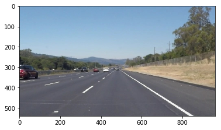

```python
#reading in an image
image = cv2.imread('test_images/solidWhiteRight.jpg')
image = cv2.cvtColor(image, cv2.COLOR_BGR2RGB)

#printing out some stats and plotting
print('This image is:', type(image), 'with dimensions:', image.shape)
plt.imshow(image)  # if you wanted to show a single color channel image called 'gray', for example, call as plt.imshow(gray, cmap='gray')
```

## Ideas for Lane Detection Pipeline

**Some OpenCV functions that might be useful for this project are:**

`cv2.inRange()` for color selection  
`cv2.fillPoly()` for regions selection  
`cv2.line()` to draw lines on an image given endpoints  
`cv2.addWeighted()` to coadd / overlay two images `cv2.cvtColor()` to grayscale or change color `cv2.imwrite()` to output images to file  
`cv2.bitwise_and()` to apply a mask to an image

## Helper Functions

Below are some helper functions to help get you started.

```python
import math

def grayscale(img):
    """Applies the Grayscale transform
    This will return an image with only one color channel
    but NOTE: to see the returned image as grayscale
    (assuming your grayscaled image is called 'gray')
    you should call plt.imshow(gray, cmap='gray')"""
    return cv2.cvtColor(img, cv2.COLOR_RGB2GRAY)
    # Or use BGR2GRAY if you read an image with cv2.imread()
    # return cv2.cvtColor(img, cv2.COLOR_BGR2GRAY)

def canny(img, low_threshold, high_threshold):
    """Applies the Canny transform"""
    return cv2.Canny(img, low_threshold, high_threshold)

def gaussian_blur(img, kernel_size):
    """Applies a Gaussian Noise kernel"""
    return cv2.GaussianBlur(img, (kernel_size, kernel_size), 0)

def region_of_interest(img, vertices):
    """
    Applies an image mask.

    Only keeps the region of the image defined by the polygon
    formed from `vertices`. The rest of the image is set to black.
    `vertices` should be a numpy array of integer points.
    """
    #defining a blank mask to start with
    mask = np.zeros_like(img)

    #defining a 3 channel or 1 channel color to fill the mask with depending on the input image
    if len(img.shape) > 2:
        channel_count = img.shape[2]  # i.e. 3 or 4 depending on your image
        ignore_mask_color = (255,) * channel_count
    else:
        ignore_mask_color = 255

    #filling pixels inside the polygon defined by "vertices" with the fill color
    cv2.fillPoly(mask, vertices, ignore_mask_color)

    #returning the image only where mask pixels are nonzero
    masked_image = cv2.bitwise_and(img, mask)
    return masked_image


def draw_lines(img, lines, color=[255, 0, 0], thickness=2):
    """
    This function draws `lines` with `color` and `thickness`.
    Lines are drawn on the image inplace (mutates the image).
    If you want to make the lines semi-transparent, think about combining
    this function with the weighted_img() function below
    """
    for line in lines:
        for x1,y1,x2,y2 in line:
            cv2.line(img, (x1, y1), (x2, y2), color, thickness)

def hough_lines(img, rho, theta, threshold, min_line_len, max_line_gap):
    """
    `img` should be the output of a Canny transform.

    Returns an image with hough lines drawn.
    """
    lines = cv2.HoughLinesP(img, rho, theta, threshold, np.array([]), minLineLength=min_line_len, maxLineGap=max_line_gap)
    line_img = np.zeros((img.shape[0], img.shape[1], 3), dtype=np.uint8)
    draw_lines(line_img, lines)
    return line_img

def weighted_img(img, initial_img, alpha=0.8, beta=1., gamma=0.):
    """
    `img` is the output of the hough_lines(), An image with lines drawn on it.
    Should be a blank image (all black) with lines drawn on it.

    `initial_img` should be the image before any processing.

    The result image is computed as follows:

    initial_img * α + img * β + γ
    NOTE: initial_img and img must be the same shape!
    """
    return cv2.addWeighted(initial_img, alpha, img, beta, gamma)
```

## Test Images

Build your pipeline to work on the images in the directory "test_images"

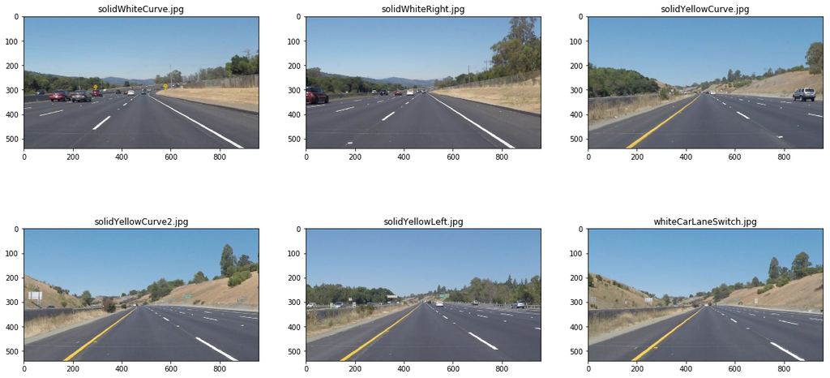

```python
import os

path = "test_images/"
files = os.listdir(path)
images = []

f, plots = plt.subplots((len(files)+3-1)//3, 3, figsize=(20,10))
plots = [plot for sublist in plots for plot in sublist]

for file, plot in zip(files, plots):
    image = cv2.cvtColor(cv2.imread(os.path.join(path, file)), cv2.COLOR_BGR2RGB)
    plot.set_title(file)
    plot.imshow(image)
    images.append((image, file))
```

## Build a Lane Finding Pipeline

Build the pipeline and run your solution on all test_images.

Try tuning the various parameters, especially the low and high Canny thresholds as well as the Hough lines parameters.

## Improve the draw_lines() function

**At this point, you should have the Hough line segments drawn onto the road. Extend your code to define a line to run the full length of the visible lane based on the line segments you identified with the Hough Transform. Try to average and/or extrapolate the line segments you've detected to map out the full extent of the lane lines. The output should draw a single, solid line over the left lane line and a single, solid line over the right lane line. The lines should start from the bottom of the image and extend out to the top of the region of interest.**

### Constant definitions

```python
yellow_lo_hsv = np.array([19,100, 0])
yellow_hi_hsv = np.array([25,255,255])

white_lo_hsv = np.array([0,0,200])
white_hi_hsv = np.array([255,30,255])

# Canny parmeters
low = 50
high = 100
```

### Create trapezoid mask

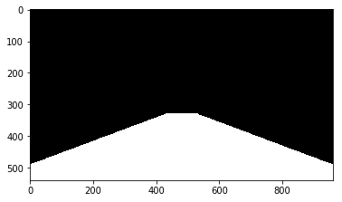

```python
# Only pixels below this boundary (number of pixels from the top) will be considered
boundary = 330
# Base black image, the results from yellow and white detection are added to this
base = np.zeros((images[0][0].shape[0], images[0][0].shape[1]))
trapezoid = np.copy(base)
polyPoints = np.array([[
    [0, 490],
    [430, boundary],
    [530, boundary],
    [960, 490],
    [960, 540],
    [0,   540]
]])

# Canny parameters
canny_low = 75
canny_high = 100

# HoughLines Parameters
rho = 2
theta = np.pi/270
threshold = 15
min_line_length = 50
max_line_gap = 100

trapezoid = cv2.fillPoly(trapezoid, polyPoints, 100)
# 430 -> 530
plt.imshow(trapezoid, cmap='gray')
```

### Some functions

```python
# Gets an HSV image and creates a mask leaving only white areas
def white_mask(img):
    return cv2.inRange(img[boundary:,:,:], white_lo_hsv, white_hi_hsv)

# Gets an HSV image and creates a mask leaving only yellow areas
def yellow_mask(img):
    return cv2.inRange(img[boundary:,:,:], yellow_lo_hsv, yellow_hi_hsv)

# Gets an HSV image and creates a mask leaving only white and yellow areas
def lines_mask(img):
    new_base = np.copy(base)
    new_base[boundary:,:] = white_mask(img)+yellow_mask(img)
    return new_base

# Gets an HSV image and creates a mask leaving only white and yellow areas INSIDE the trapezoid
def filter_lines_trapezoid(img):
    return cv2.bitwise_and(lines_mask(img), trapezoid)

# Gets an HSV image and gets the canny image of the mask of the white and yellow areas INSIDE the trapezoid
def get_canny_lines(img):
    return cv2.Canny(filter_lines_trapezoid(img).astype(np.uint8), canny_low, canny_high)

# Gets a single line and returns it's slope (over y to make extrapolation easier)
def slope(line):
    #x1,y1,x2,y2 = *line
    return (line[0]-line[2])/(line[1]-line[3])

# Gets an array of lines and returns the average slope and an array of all the individual slopes
def average_slope(lines):
    slopes = np.zeros(len(lines))
    for i, line in enumerate(lines):
        slopes[i] = slope(line)
    return np.average(slopes), slopes

# Gets an array of lines and separates them into left and right groups based on the ir average slope
# Returns an array for the left lines and an array for the right lines
def separate(lines):
    left = []
    right = []
    avg_slope, slopes = average_slope(lines)
    for i, line in enumerate(lines):
        if slopes[i] <= avg_slope:
            left.append(line)
        else:
            right.append(line)
    return np.array(left), np.array(right)

# Gets an array of lines with similar slopes and outputs a line going from the
#  top-most starting point of the lines all the way down to the bottom of the image.
#  This new line has the average slope of al the lines.
def unify_lines(lines):
    avg_slope = average_slope(lines)[0]
    start_point = lines[np.argmin(np.amin(lines[:,[1,3]], axis=1))]
    endX = round((540-start_point[1]) * avg_slope + start_point[0])
    offset = 2*np.argmin(start_point[[1,3]])
    # This output format makes it clieaner to feed the output to cv2.line
    return ((start_point[0+offset], start_point[1+offset]), (int(endX), 540))

# Gets an HSV image and returns the lines describing the left and right lane separators
def get_image_lines(img):
    # Get lane dividers
    lines = cv2.HoughLinesP(get_canny_lines(img), rho, theta, threshold, np.array([]), min_line_length, max_line_gap)[:,0]
    # Group into left and right images
    left, right = separate(lines)
    left  = unify_lines(left)
    right = unify_lines(right)
    return left, right
```

## Drawing images

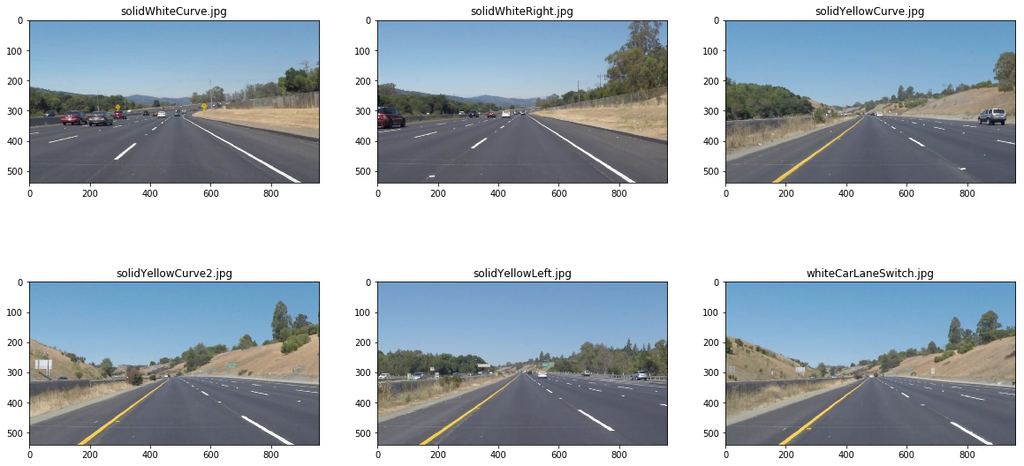

```python
f, plots = plt.subplots((len(images)+3-1)//3, 3, figsize=(20,10))
plots = [plot for sublist in plots for plot in sublist]

for image, plot in zip(images, plots):
    plot.set_title(image[1])
    plot.imshow(image[0])
```

## Drawing images with detected lines

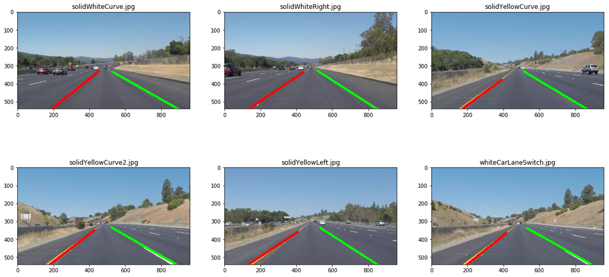

```python
f, plots = plt.subplots((len(images)+3-1)//3, 3, figsize=(20,10))
plots = [plot for sublist in plots for plot in sublist]

for image, plot in zip(images, plots):
    # Convert to HSV to pass it to get_image_lines
    left, right = get_image_lines(cv2.cvtColor(image[0], cv2.COLOR_RGB2HSV))
    cv2.line(image[0],  left[0],  left[1], (255,   0, 0),12)
    cv2.line(image[0], right[0], right[1], (  0, 255, 0),12)
    plot.set_title(image[1])
    plot.imshow(image[0])
```